# Predicting box office Revenue

Dennis Mugendi

16/10/2021

# Introduction

1. Exploratory data analysis,
2. Feature engineering,
3. Treating missing values, and
4. Machine learning using Random Forest.

Loading the required packages.

```r
library(tidyverse)
library(plotly)
library(ggthemes)
library(viridis)
library(corrplot)
library(gridExtra)# Grids for visualization
library(VIM)
library(lubridate)# Working with  dates
library(randomForest)
```

Read in the data.

```r
train_data = read.csv("C:/Users/adm/Documents/Datasets/Post office/train.csv",na.strings = c("","#N/A","[]","0"))
test_data = read.csv("C:/Users/adm/Documents/Datasets/Post office/test.csv",na.strings = c("","#N/A","[]","0"))

full_data <-bind_rows(train_data,test_data)
```

Taking a glimpse of the data.

```r
glimpse(full_data)
```

```
## Rows: 7,398
## Columns: 23
## $ ï..id                 <int> 1, 2, 3, 4, 5, 6, 7, 8, 9, 10, 11, 12, 13, 14, 1~
## $ belongs_to_collection <chr> "[{'id': 313576, 'name': 'Hot Tub Time Machine C~
## $ budget                <int> 14000000, 40000000, 3300000, 1200000, NA, 800000~
## $ genres                <chr> "[{'id': 35, 'name': 'Comedy'}]", "[{'id': 35, '~
## $ homepage              <chr> NA, NA, "http://sonyclassics.com/whiplash/", "ht~
## $ imdb_id               <chr> "tt2637294", "tt0368933", "tt2582802", "tt182148~
## $ original_language     <chr> "en", "en", "en", "hi", "ko", "en", "en", "en", ~
## $ original_title        <chr> "Hot Tub Time Machine 2", "The Princess Diaries ~
## $ overview              <chr> "When Lou, who has become the \"father of the In~
## $ popularity            <dbl> 6.575393, 8.248895, 64.299990, 3.174936, 1.14807~
## $ poster_path           <chr> "/tQtWuwvMf0hCc2QR2tkolwl7c3c.jpg", "/w9Z7A0GHEh~
## $ production_companies  <chr> "[{'name': 'Paramount Pictures', 'id': 4}, {'nam~
## $ production_countries  <chr> "[{'iso_3166_1': 'US', 'name': 'United States of~
## $ release_date          <chr> "2/20/15", "8/6/04", "10/10/14", "3/9/12", "2/5/~
## $ runtime               <int> 93, 113, 105, 122, 118, 83, 92, 84, 100, 91, 119~
## $ spoken_languages      <chr> "[{'iso_639_1': 'en', 'name': 'English'}]", "[{'~
## $ status                <chr> "Released", "Released", "Released", "Released", ~
## $ tagline               <chr> "The Laws of Space and Time are About to be Viol~
## $ title                 <chr> "Hot Tub Time Machine 2", "The Princess Diaries ~
## $ Keywords              <chr> "[{'id': 4379, 'name': 'time travel'}, {'id': 96~
## $ cast                  <chr> "[{'cast_id': 4, 'character': 'Lou', 'credit_id'~
## $ crew                  <chr> "[{'credit_id': '59ac067c92514107af02c8c8', 'dep~
## $ revenue               <int> 12314651, 95149435, 13092000, 16000000, 3923970,~
```

A lot of these variables ( e.g., `belongs_to_collection`, `genres`, and `cast`) look quite messy.Because of this i will use *regular expressions* and extract the appropriate information before using them in the model.

# Exploratory Data Analysis

Plotting the existing variables `budget`, `runtime`, and `popularity` in order to see their relation to the prediction variable revenue.

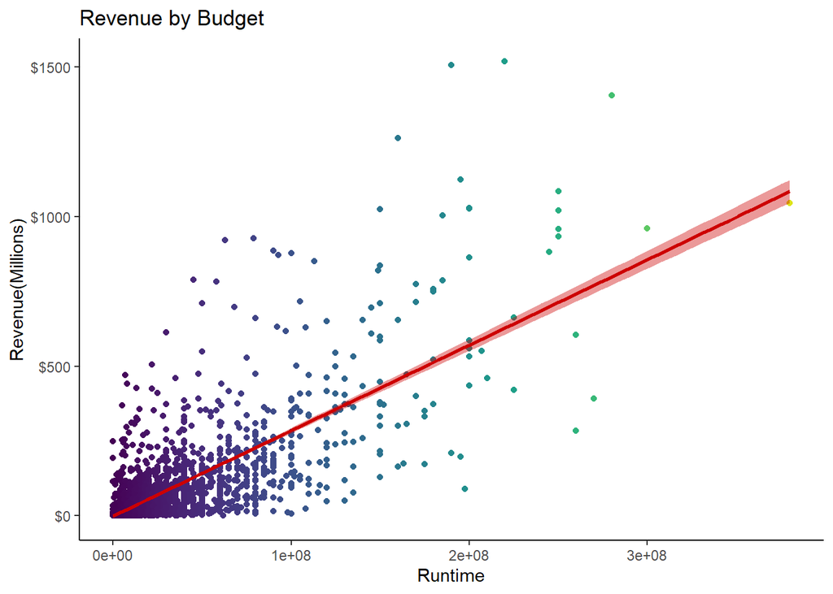

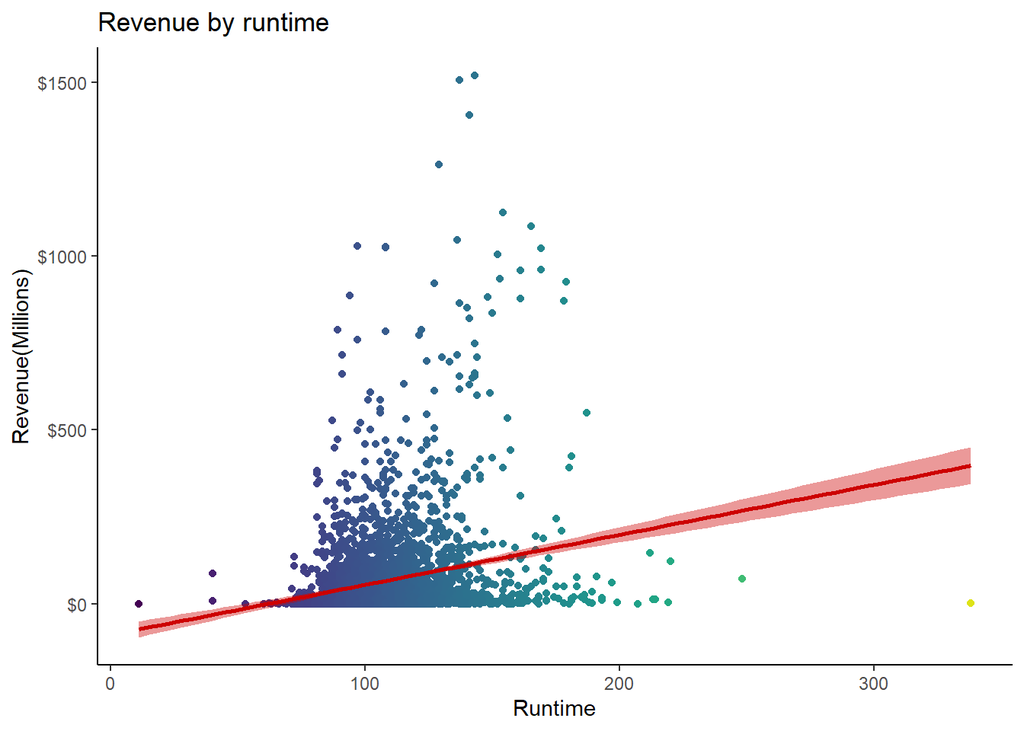

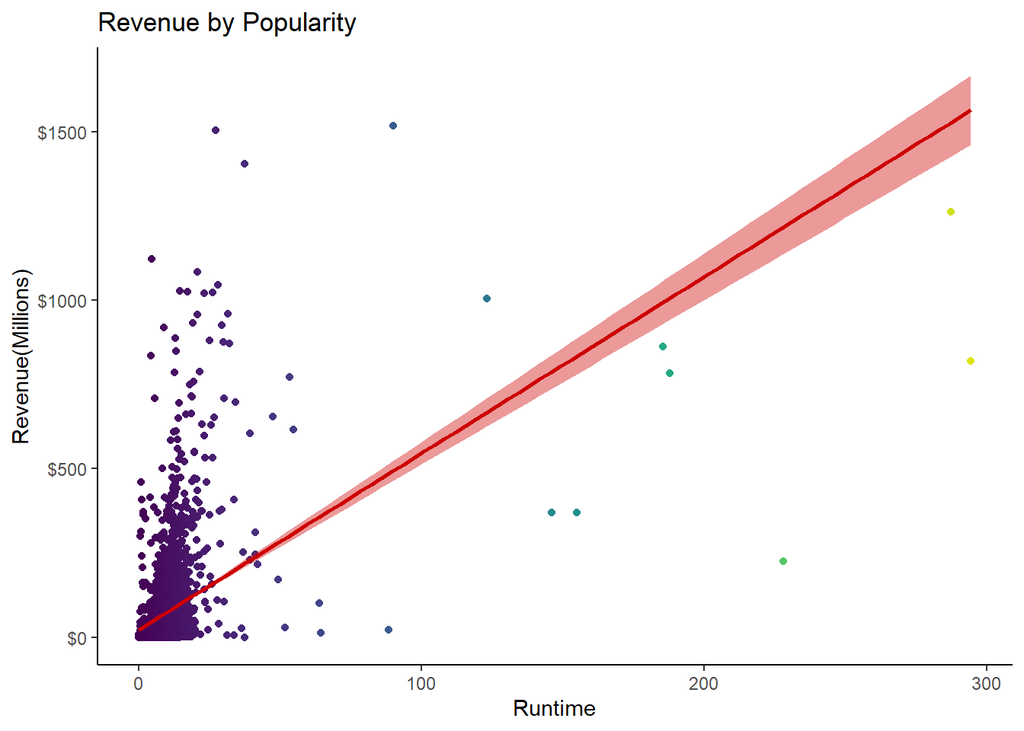

Some clear trends are an increase in budget and budget tend to lead to higher revenue. Runtime seems to show this trend although its not as strong.

# Feature Engineering.

## Collection

The strings in `belongs_to_collection` are messy and contain unneeded information. Using regular expression to extract the collection names from these strings.

```r
full_data$collection_name<-str_extract(full_data$belongs_to_collection,
                                       pattern = "(?<=name\\'\\:\\s{1}\\').+(?=\\'\\,\\s{1}\\'poster)")
```

Having extracted the collection name lets check the biggest collection.

```r
full_data[1:3000,] %>%
  group_by(collection_name) %>%
  summarise(movie_count=n()) %>%
  arrange(desc(movie_count)) %>%
  filter(!is.na(collection_name)) %>%
  head(10)
```

```
## # A tibble: 10 x 2
##    collection_name                        movie_count
##    <chr>                                        <int>
##  1 James Bond Collection                           16
##  2 Friday the 13th Collection                       7
##  3 The Pink Panther (Original) Collection           6
##  4 PokÃ©mon Collection                              5
##  5 Police Academy Collection                        5
##  6 Alien Collection                                 4
##  7 Ice Age Collection                               4
##  8 Paranormal Activity Collection                   4
##  9 Rambo Collection                                 4
## 10 Resident Evil Collection                         4
```

As each collection is small will engineer a new variable that consist of either being in a collection or not being in a collection.

```r
full_data$collection[!is.na(full_data$belongs_to_collection)] <- 'Collection'
full_data$collection[is.na(full_data$belongs_to_collection)] <-
'No Collection'
```

Plotting the new variables to visualize how the two levels differ on revenue.

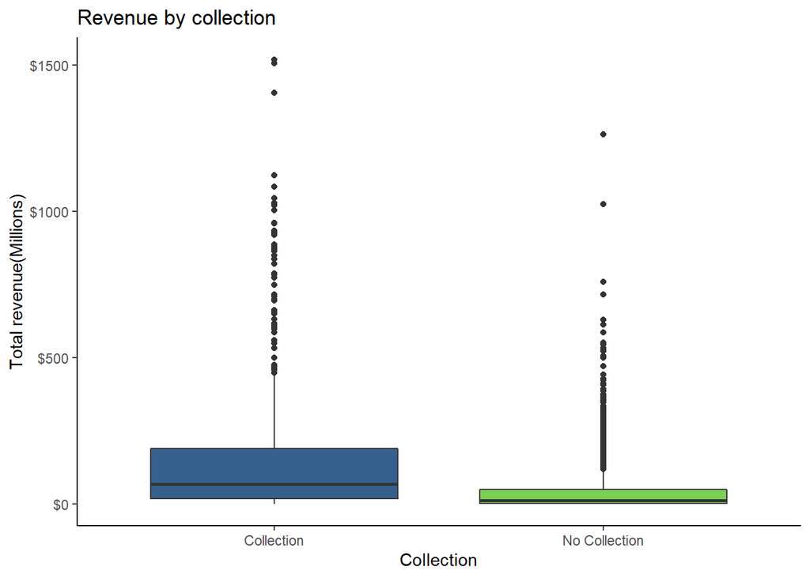

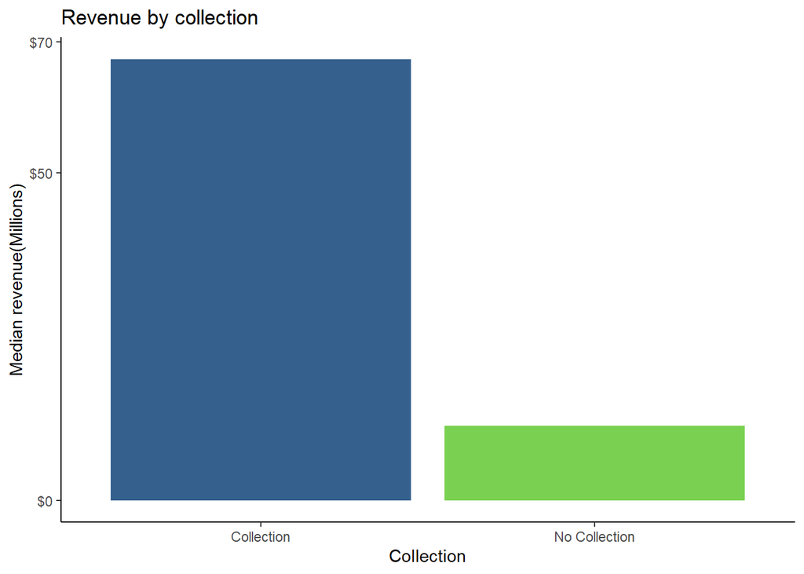

On average, movies that are in collections seem to be getting higher revenues as seen from the box plot and bar plot.

## Main genre

Will extract the first genre from the `genres` strings to get the main genre for each movie. First, create a vector with the genres we want to extract.Next, we will extract the genres and add them to a new variable called `main_genre.`

```r
genres_matching_point <- "Comedy|Horror|Action|Drama|Documentary|Science Fiction|Crime|Fantasy|Thriller|Animation|Adventure|Mystery|War|Romance|Music|Family|Western|History|TV Movie|Foreign"

full_data$main_genre <- str_extract(full_data$genres, genres_matching_point)
```

Next, plot `main_genre` to find (1) how many movies are there per genre and (2) the median revenue by genre.

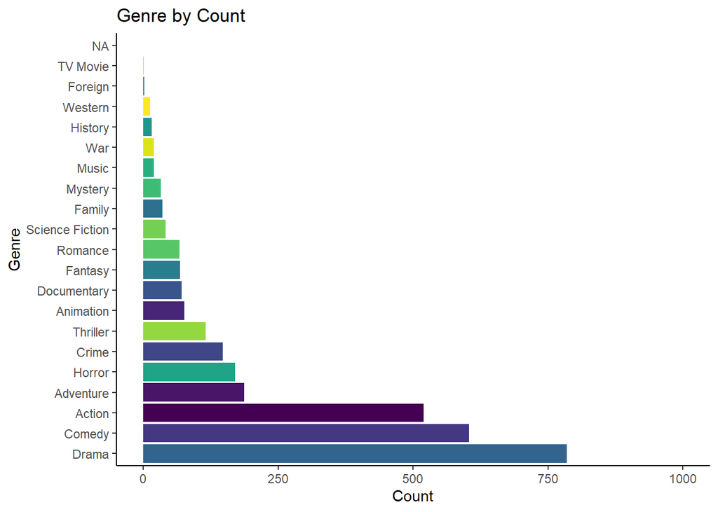

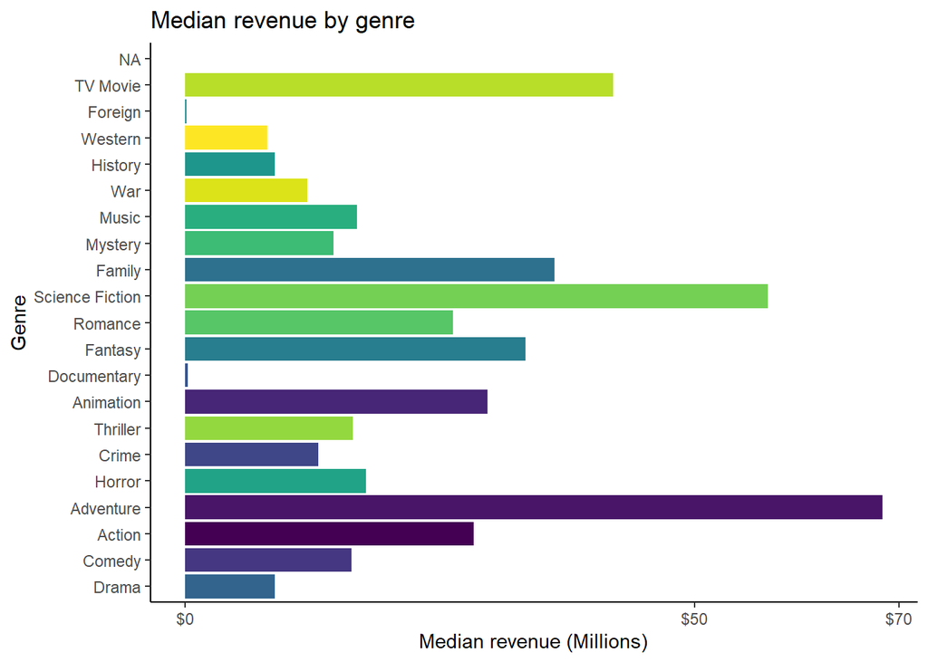

Different genres seem to be making different revenues.Adventure movies seem to have the highest median revenue, followed by science fiction.The median values of genres with few counts, such as TV movie might be over / underestimated due to small sample sizes.

## Production company id

Extract the first (and main) production company id from `production_companies` and create a new variable `prod_comp_id.`

```r
full_data$prod_comp_id <- str_extract(full_data$production_companies,
                                      pattern = "([0-9]+)")
```

```r
str(full_data$prod_comp_id)
```

```
##  chr [1:7398] "4" "2" "2266" NA NA NA "768" NA "2" "97" "60" "306" "27" ...
```

Plotting this variable to see how it affects revenue.

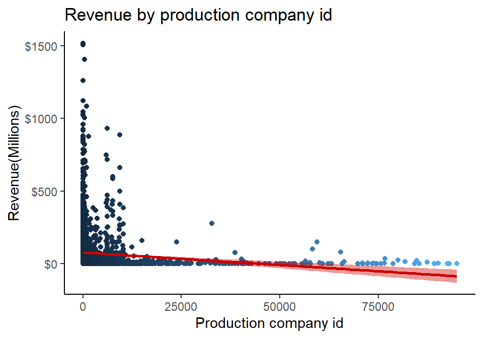

Production companies with lower numbered id’s seem to be making more revenue compared to those with higher id’s. Checking correlation to confirm this.

```r
cor(full_data$revenue,full_data$prod_comp_id,use = 'complete.obs')
```

```
## [1] -0.1282278
```

A *small* negative correlation seems to be present.

## Top production companies.

Extraction the main production companies from `production_companies`.

```r
full_data$prod_comp_name <-gsub('(^\\[\\{\'name\'\\:\\s\'|\'\\,\\s\'id.*)', '',full_data$production_companies)
```

Check the top production companies ordered by number of movies produced.

```r
full_data[1:3000,]%>%
  group_by(prod_comp_name)%>%
  summarise(movie_count = n())%>%
  arrange(desc(movie_count))%>%
  filter(!is.na(prod_comp_name))%>%
  head(10)
```

```
## # A tibble: 10 x 2
##    prod_comp_name                         movie_count
##    <chr>                                        <int>
##  1 Universal Pictures                             167
##  2 Paramount Pictures                             158
##  3 Twentieth Century Fox Film Corporation         122
##  4 Columbia Pictures                               90
##  5 Warner Bros.                                    70
##  6 New Line Cinema                                 69
##  7 Walt Disney Pictures                            62
##  8 Columbia Pictures Corporation                   44
##  9 TriStar Pictures                                44
## 10 United Artists                                  41
```

```r
full_data$top_prod_comp[full_data$prod_comp_name == 'Universal Pictures'] <- 'Universal Pictures'
full_data$top_prod_comp[full_data$prod_comp_name == 'Paramount Pictures'] <- 'Paramount Pictures'
full_data$top_prod_comp[full_data$prod_comp_name == ' Twentieth Century Fox Film Corporation'] <-'Twentieth Century Fox Film Corporation'
full_data$top_prod_comp[full_data$prod_comp_name == 'Columbia Pictures'] <- 'Columbia Pictures'
full_data$top_prod_comp[full_data$prod_comp_name == 'New Line Cinema'] <-'New Line Cinema'
full_data$top_prod_comp[full_data$prod_comp_name == 'Warner Bros.'] <-'Warner Bros.'
full_data$top_prod_comp[full_data$prod_comp_name == 'Walt Disney Pictures'] <-'Walt Disney Pictures'

full_data$top_prod_comp[is.na(full_data$prod_comp_name)] <-'Other'
```

Looking at the effect of this variable on revenue.

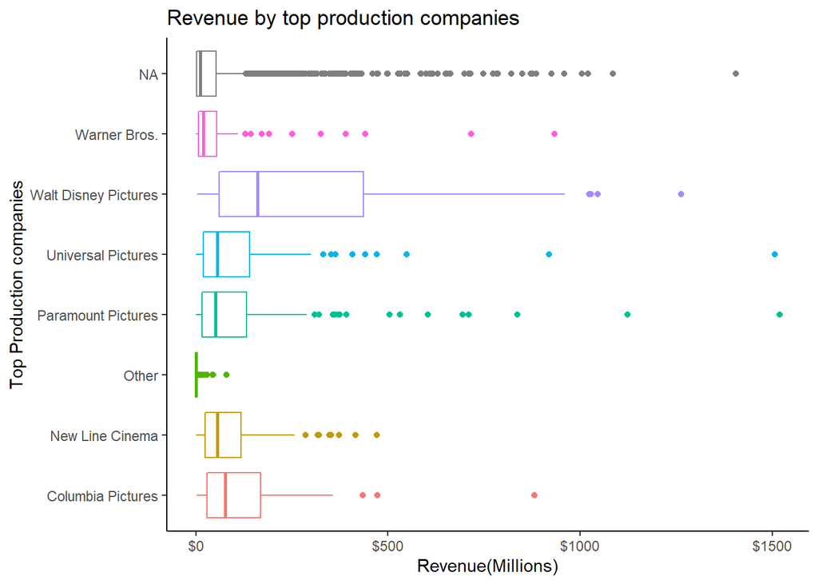

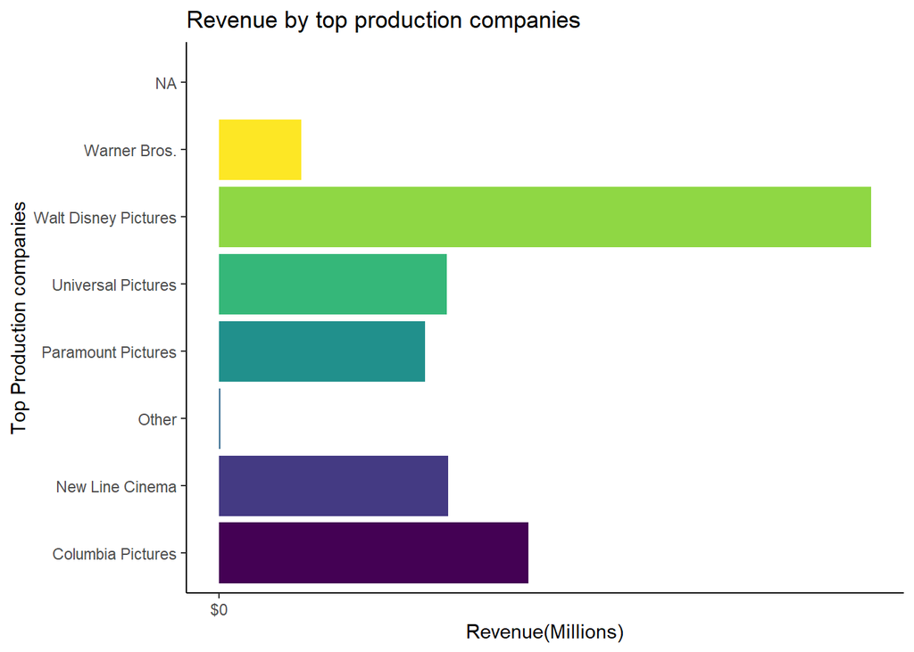

It can be seen that the average revenue for alot of top production companies is higher than the ‘other’ production companies.

## Production company size

Creating `prod_comp_size` (production company size – *big producer* v. *small producer*). Assign companies that have at least 60 movies each as big producers and all the rest as small producers. Assume that all NAs are small producers.

```r
full_data$prod_comp_size[full_data$prod_comp_name == 'Universal Pictures']<- 'Big Producer'
full_data$prod_comp_size[full_data$prod_comp_name == 'Paramount Pictures']<- 'Big Producer'
full_data$prod_comp_size[full_data$prod_comp_name =='Twentieth Century Fox Film Corporation']<- 'Big Producer'
full_data$prod_comp_size[full_data$prod_comp_name =='Columbia Pictures']<- 'Big Producer'
full_data$prod_comp_size[full_data$prod_comp_name =='New Line Cinema']<- 'Big Producer'
full_data$prod_comp_size[full_data$prod_comp_name =='Warner Bros.']<- 'Big Producer'
full_data$prod_comp_size[full_data$prod_comp_name == 'Walt Disney Pictures']<- 'Big Producer'
full_data$prod_comp_size[is.na(full_data$prod_comp_size)]<- 'Small Producer'
```

Looking at how the new data affects revenue.

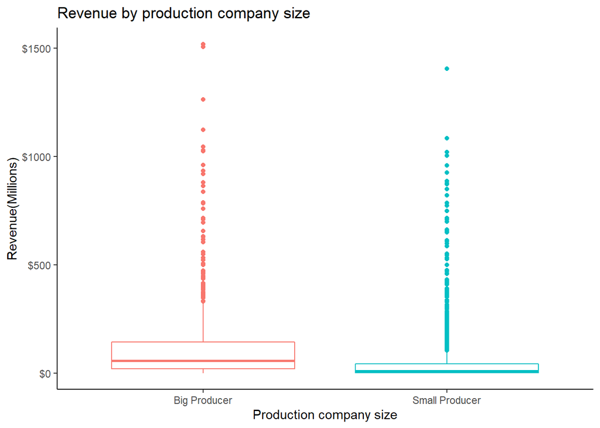

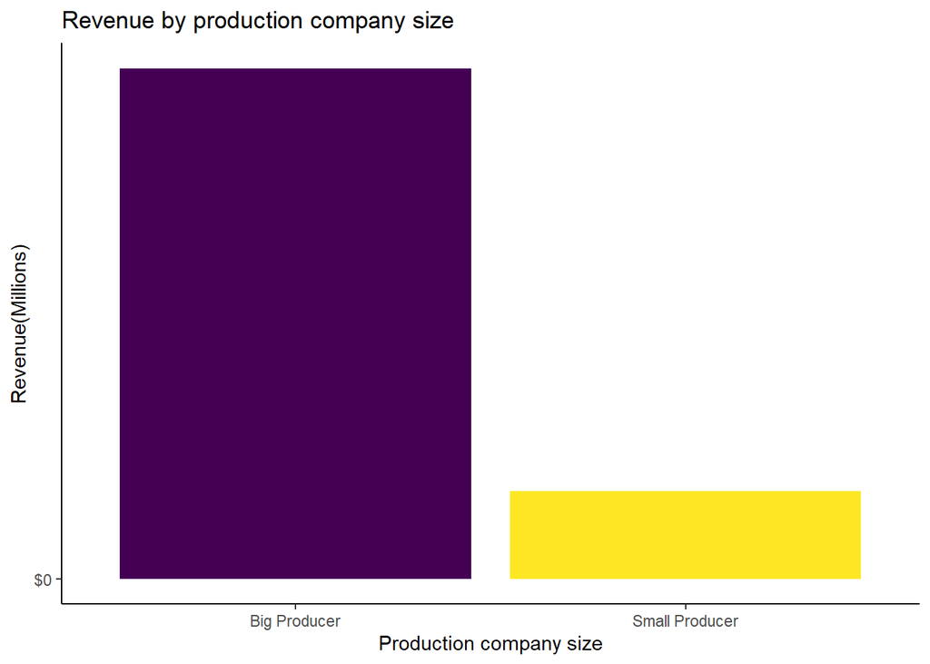

It can be seen that big production companies are, on average, making more than smaller production comapnies.